# EDS241: Assignment 2

Linus Ghanadan

02/09/2024

**Reminders:** Make sure to read through the setup in markdown. Remember to fully report/interpret your results and estimates (in writing) + present them in tables/plots.

# 1 Part 1 Treatment Ignorability Assumption and Applying Matching Estimators (19 points):

The goal is to estimate the causal effect of maternal smoking during pregnancy on infant birth weight using the treatment ignorability assumptions. The data are taken from the National Natality Detail Files, and the extract “SMOKING_EDS241.csv”’ is a random sample of all births in Pennsylvania during 1989-1991. Each observation is a mother-infant pair. The key variables are:

**The outcome and treatment variables are:**

birthwgt=birth weight of infant in grams

tobacco=indicator for maternal smoking

**The control variables are:**

mage (mother’s age), meduc (mother’s education), mblack (=1 if mother identifies as Black), alcohol (=1 if consumed alcohol during pregnancy), first (=1 if first child), diabete (=1 if mother diabetic), anemia (=1 if mother anemic)

```r
# Load data for Part 1
smoking_df <- read_csv(here("data", "SMOKING_EDS241.csv"))
```

## 1.1 Mean Differences, Assumptions, and Covariates *(3 pts)*

1. What is the mean difference in birth weight of infants with smoking and non-smoking mothers [1 pts]? Under what assumption does this correspond to the average treatment effect of maternal smoking during pregnancy on infant birth weight [0.5 pts]? Calculate and create a table demonstrating the differences in the mean proportions/values of covariates observed in smokers and non-smokers (remember to report whether differences are statistically significant) and discuss whether this provides empirical evidence for or against this assumption. Remember that this is observational data. What other quantitative empirical evidence or test could help you assess the former assumption? [1.5 pts: 0.5 pts table, 1 pts discussion]

```r
#### Calculate mean difference
ATE <- mean(smoking_df$birthwgt[smoking_df$tobacco == 1]) - mean(smoking_df$birthwgt[smoking_df$tobacco == 0])
ATE
```

```
## [1] -244.5394
```

```r
#### Calculate statistical significance for mean difference calculation
t.test(smoking_df$birthwgt[smoking_df$tobacco == 1], smoking_df$birthwgt[smoking_df$tobacco == 0])
```

```
##
##  Welch Two Sample t-test
##
## data:  smoking_df$birthwgt[smoking_df$tobacco == 1] and smoking_df$birthwgt[smoking_df$tobacco == 0]
## t = -58.932, df = 26945, p-value < 0.00000000000000022
## alternative hypothesis: true difference in means is not equal to 0
## 95 percent confidence interval:
##  -252.6727 -236.4060
## sample estimates:
## mean of x mean of y
##  3185.747  3430.286
```

```r
#### Covariate Calculations and Tables (feel free to use code from Assignment 1 key)

# Selecting binary and continuous variables from data set
covariate_binary <- smoking_df %>%
  select(tobacco, anemia, diabete, alcohol, mblack, first)
covariate_continuous <- smoking_df %>%
  select(tobacco, mage, meduc)

# Initialize empty data frames to store test results
prop_test_results <- data.frame()
t_test_results <- data.frame()

# Identifying binary variables for proportion tests
for (i in names(covariate_binary)) {

  # Splitting the data into treated and untreated groups for the current variable
  treated <- covariate_binary %>%
    filter(tobacco == 1) %>%
    pull(!!sym(i))
  untreated <- covariate_binary %>%
    filter(tobacco == 0) %>%
    pull(!!sym(i))

  # Performing the proportion test
  prop_test_result <- prop.test(x = c(sum(treated), sum(untreated)),
                                n = c(length(treated), length(untreated)),
                                correct = FALSE)

  # Storing the tidy results of the proportion test in data frame
  prop_test_result_tidy <- broom::tidy(prop_test_result)
  prop_test_result_tidy$Variable <- i
  prop_test_results <- rbind(prop_test_results, prop_test_result_tidy)

}

# Exclude tobacco from the list of variables to process
variable_names <- setdiff(names(covariate_continuous), "tobacco")

for (i in variable_names) {
  # Dynamically creating the formula for the t-test
  formula <- as.formula(paste(i, "~ tobacco"))

  # Performing the t-test
  t_test_result <- t.test(formula, data = covariate_continuous, na.action = na.omit)

  # Storing the tidy results of the t-test in the data frame
  t_test_result_tidy <- broom::tidy(t_test_result)
  t_test_result_tidy$Variable <- i
  t_test_results <- rbind(t_test_results, t_test_result_tidy)

}

#### Present results

# Combining the results of proportion and t-tests into a single data frame
combined_results <- bind_rows(
prop_test_results %>% select(Variable, estimate1, estimate2, p.value), t_test_results %>% select(Variable, estimate1, estimate2, p.value)
)

# Creating a table for output using kable
combined_results_table <- kable(combined_results, col.names = c("Variable",
                                                                "Proportion or Mean Control",
                                                                "Proportion or Mean Treated", "P-Value"),
                                caption = "Treated and Untreated Pre-treatment Proportion and T-Test Results")

# Displaying the table
combined_results_table
```

Treated and Untreated Pre-treatment Proportion and T-Test Results

| Variable | Proportion or Mean Control | Proportion or Mean Treated | P-Value |
| --- | --- | --- | --- |
| tobacco | 1.0000000 | 0.0000000 | 0.0000000 |
| anemia | 0.0141031 | 0.0078005 | 0.0000000 |
| diabete | 0.0175187 | 0.0173636 | 0.8858005 |
| alcohol | 0.0441825 | 0.0071033 | 0.0000000 |
| mblack | 0.1354121 | 0.1086279 | 0.0000000 |
| first | 0.3645879 | 0.4360900 | 0.0000000 |
| mage | 27.4530853 | 25.5385632 | 0.0000000 |
| meduc | 13.2394207 | 11.9209454 | 0.0000000 |

The mean difference in birth weight of infants with smoking mothers, compared to non-smoking mothers, is -244.5 grams, and our 95% confidence interval is from -252.7 grams to -236.4 grams. Our calculated mean difference is also the ATE under the assumption that mothers were randomly assigned to the smoking and non-smoking groups.

With the exception of the diabetes covariate, the differences in the mean proportions/values of all other covariates observed in smokers and non-smokers were each statistically significant at alpha level of 0.01. This provides empirical evidence against the assumption that randomization occurred because our result shows that the two groups (smoking mothers and non-smoking mothers) are systematically different from one another for all covariates looked at in this study except diabetes.

To help us further assess the randomization assumption, we could compute the standard difference between the two groups (smoking mothers and non-smoking mothers) for each covariate variable and see how many of these standard differences were significantly different than zero based on p-value. We could also run a chi-squared test to assess whether differences across all covariates were altogether significantly different than zero based on p-value.

## 1.2 ATE and Covariate Balance *(3 pts)*

2. Assume that maternal smoking is randomly assigned conditional on the observable covariates listed above. Estimate the effect of maternal smoking on birth weight using an OLS regression with NO linear controls for the covariates [0.5 pts]. Perform the same estimate including the control variables [0.5 pts]. Next, compute indices of covariate imbalance between the treated and non-treated regarding these covariates (see example file from class). Present your results in a table [1 pts]. What do you find and what does it say regarding whether the assumption you mentioned responding to a) is fulfilled? [1 pts]

```r
#### ATE Regression univariate
model_1 <- lm(birthwgt ~ tobacco, data = smoking_df)


#### ATE with covariates
model_2 <- lm(birthwgt ~ tobacco + anemia + diabete + alcohol + mblack + first + mage + meduc, data = smoking_df)

#### Present Regression Results

# Store coefficients from model_1 and model_2
coefficients_model_1 <- model_1$coefficients
coefficients_model_2 <- model_2$coefficients

# Create a vector for model_1 coefficients aligned with model_2 coefficients
aligned_model_1 <- setNames(rep(NA, length(coefficients_model_2)), names(coefficients_model_2))

# Fill aligned_model_1 with coefficients_model_1 values where names match and combine into one data frame
names_in_both <- names(coefficients_model_1) %in% names(coefficients_model_2)
aligned_model_1[names(coefficients_model_1)[names_in_both]] <- coefficients_model_1[names_in_both]
combined_df <- data.frame(model_1 = aligned_model_1, model_2 = coefficients_model_2)

# Extract standard errors from each model summary
se_model_1 <- summary(model_1)$coefficients[, "Std. Error"]
se_model_2 <- summary(model_2)$coefficients[, "Std. Error"]

# Align se_model_1 with the coefficient names of model_2, filling missing SEs with NA
aligned_se_model_1 <- setNames(rep(NA, length(se_model_2)), names(se_model_2))
names_in_model_1 <- names(se_model_1) %in% names(se_model_2)
aligned_se_model_1[names(se_model_1)[names_in_model_1]] <- se_model_1[names_in_model_1]

# Append the SEs as new rows in the data frame and reorder columns
combined_df_with_se <- cbind(combined_df,
                             SE_model_1 = aligned_se_model_1,
                             SE_model_2 = se_model_2) %>%
  select(model_1, SE_model_1, model_2, SE_model_2)

# Present table using kable package
kable(combined_df_with_se, caption = "ATE regression without (model 1) and with (model 2) covariates")
```

ATE regression without (model 1) and with (model 2) covariates

|  | model_1 | SE_model_1 | model_2 | SE_model_2 |
| --- | --- | --- | --- | --- |
| (Intercept) | 3430.2863 | 1.790782 | 3362.2582445 | 11.9272609 |
| tobacco | -244.5394 | 4.078907 | -228.0730765 | 4.1774982 |
| anemia | NA | NA | -4.7963916 | 16.7544421 |
| diabete | NA | NA | 73.2275309 | 12.1035155 |
| alcohol | NA | NA | -77.3497487 | 13.4653594 |
| mblack | NA | NA | -240.0303000 | 5.1062333 |
| first | NA | NA | -96.9441154 | 3.4466349 |
| mage | NA | NA | -0.6940244 | 0.3565637 |
| meduc | NA | NA | 11.6883416 | 0.8604935 |

```r
#### Compute indices of covariate imbalance (pre-matching)
xBalance(birthwgt ~ tobacco + anemia + diabete + alcohol + mblack + first + mage + meduc,
         data = smoking_df, report = c("std.diffs", "chisquare.test", "p.values")) %>%
  kbl(caption = "Indices of covariate imbalance (before matching)") %>%  # Generate table
  kable_classic(full_width = FALSE)
```

Indices of covariate imbalance (before matching)

|  | std.diff.unstrat | p.unstrat |
| --- | --- | --- |
| tobacco | -0.0003811 | 0.000000 |
| anemia | -0.0000293 | 0.000006 |
| diabete | 0.0000378 | 0.000000 |
| alcohol | -0.0000940 | 0.000000 |
| mblack | -0.0003211 | 0.000000 |
| first | -0.0001533 | 0.000000 |
| mage | 0.0001937 | 0.000000 |
| meduc | 0.0002057 | 0.000000 |

|  | chisquare | df | p.value |
| --- | --- | --- | --- |
| unstrat | 6752.456 | 8 | 0 |

Using an OLS regression with no linear controls for the covariates, we estimate the effect of maternal smoking on birth weight to be -244.5 grams. Using an OLS regression with linear controls for the covariates, we estimate the effect of maternal smoking on birth weight to be -228.1 grams.

When we calculate the standard differences between the two groups (smoking mothers and non-smoking mothers) for each covariate variable, we find that the standard differences for each of the seven covariate variables are significantly different than zero at an alpha of 0.01. When we run the chi-squared test, we reject the null hypothesis that the difference between all covariates altogether for the two groups (smoking mothers and non-smoking mothers) was equal to zero at an alpha of 0.01. The standard differences and the chi-squared test provide further empirical evidence against the assumption that randomization occurred because our results show that the two groups (smoking mothers and non-smoking mothers) are systematically different from one another in terms of the covariates.

## 1.3 Propensity Score Estimation *(3 pts)*

3. Next, estimate propensity scores (i.e. probability of being treated) for the sample, using the provided covariates. Create a regression table reporting the results of the regression and discuss what the covariate coefficients indicate and interpret one coefficient [1.5 pts]. Create histograms of the propensity scores comparing the distributions of propensity scores for smokers (‘treated’) and non-smokers (‘control’), discuss the overlap and what it means [1.5 pts].

```r
#### Propensity Scores

# Estimation of propensity scores with the glm function and logit model
ps_reg <- glm(tobacco ~ anemia + diabete + alcohol + mblack + first + mage + meduc,
          data = smoking_df, family = binomial())

#### Present regression result

# Extracting the coefficients table
summary_reg <- summary(ps_reg)
coefficients_df <- summary_reg$coefficients

# Using kable to format the table
kable(coefficients_df, caption = "Propensity scores before matching")
```

Propensity scores before matching

|  | Estimate | Std. Error | z value | Pr(>\|z\|) |
| --- | --- | --- | --- | --- |
| (Intercept) | 3.4932967 | 0.0666128 | 52.441812 | 0.0000000 |
| anemia | 0.3339523 | 0.0793667 | 4.207713 | 0.0000258 |
| diabete | 0.1595334 | 0.0658605 | 2.422291 | 0.0154230 |
| alcohol | 2.0266407 | 0.0603530 | 33.579793 | 0.0000000 |
| mblack | -0.1334468 | 0.0265866 | -5.019324 | 0.0000005 |
| first | -0.3791667 | 0.0193026 | -19.643270 | 0.0000000 |
| mage | -0.0405619 | 0.0019309 | -21.007234 | 0.0000000 |
| meduc | -0.2972694 | 0.0051521 | -57.698672 | 0.0000000 |

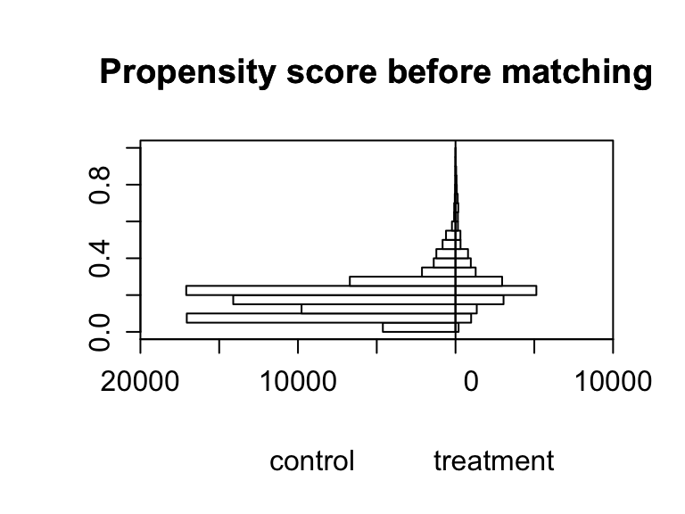

```r
#### PS Histogram Unmatched

# Attach the predicted propensity score to the data frame
smoking_df$psvalue <- predict(ps_reg, type  = "response")

# Drawing back to back histograms for propensity scores for treated and non-treated before matching
histbackback(split(smoking_df$psvalue, smoking_df$tobacco),
             main = "Propensity score before matching", xlab=c("control",   "treatment"))
```

## 1.4 Matching Balance *(3 pts)*

4. Next, match treated/control mothers using your estimated propensity scores and nearest neighbor matching. Compare the balancing of pretreatment characteristics (covariates) between treated and non-treated units in the original dataset (from c) with the matched dataset (think about comparing histograms/regressions) [2 pts]. Make sure to report and discuss the balance statistics [1 pts].

```r
#### Nearest-neighbor Matching

# Match using   nearest-neighbor approach (treated units are assigned the non-treated unit with the closest propensity score as match)
nn_matching <- matchit(tobacco ~ anemia + diabete + alcohol + mblack + first + mage + meduc, data = smoking_df, method = "nearest", ratio = 1)
match_data = match.data(nn_matching)


#### Covariate Imbalance post matching:

# Computing indices of covariate imbalance after matching
xBalance(tobacco ~ anemia + diabete + alcohol + mblack + first + mage + meduc, data = match_data,
         report = c("std.diffs", "chisquare.test", "p.values")) %>%
  kbl(caption = "Indices of covariate imbalance (after matching)") %>% # Generate table
  kable_classic(full_width = FALSE)
```

Indices of covariate imbalance (after matching)

|  | std.diff.unstrat | p.unstrat |
| --- | --- | --- |
| anemia | 0.0061509 | 0.5578802 |
| diabete | 0.0021077 | 0.8408575 |
| alcohol | 0.1116157 | 0.0000000 |
| mblack | 0.0103614 | 0.3235874 |
| first | 0.0009158 | 0.9304778 |
| mage | 0.0096451 | 0.3581627 |
| meduc | 0.0399657 | 0.0001408 |

|  | chisquare | df | p.value |
| --- | --- | --- | --- |
| unstrat | 124.2445 | 7 | 0 |

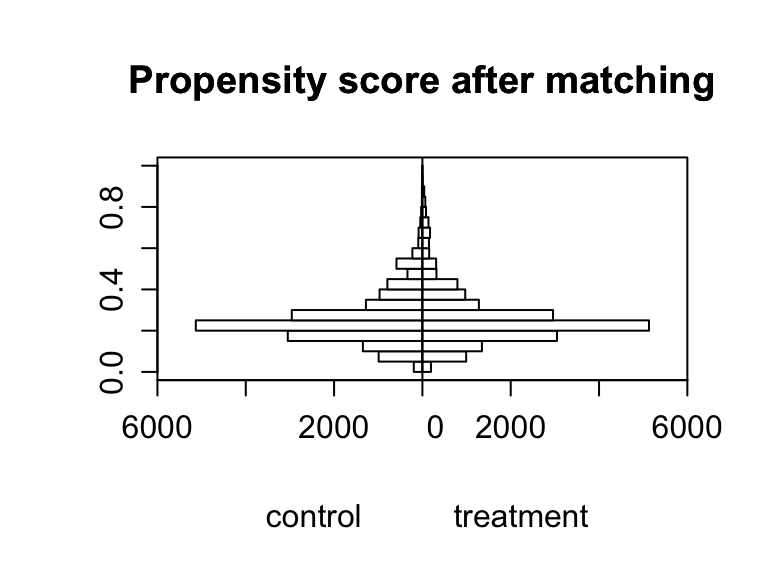

```r
#### Histogram of PS after matching

# Drawing back to back histograms for propensity scores for treated and non-treated after matching
histbackback(split(match_data$psvalue, match_data$tobacco),
             main= "Propensity score after matching", xlab=c("control", "treatment"))
```

After applying nearest neighbor matching for all treated units (newborns that experienced maternal smoking), our histogram looks very even between the two groups (non-smoking and smoking mothers), indicating that the propensity score for an individual newborn no longer seems to a determining factor for which group (non-smoking or smoking mothers) that the newborn was a part of. In our previous histogram, it was clear that newborns assigned lower propensity scores were more likely to be in the control group (have a non-smoking mother). After matching, there is also a much greater balance in the covariates across each of the two groups (smoking and non-smoking mother). Looking at our standard differences for the covariate variables, only drinking alcohol while pregnant and years of mother education still have statistically significant differences between the treatment (smoking mother) and control (non-smoking mother) groups at an alpha level of 0.01. For comparison, in the standard difference tests we ran prior to matching, all covariate variables had statistically significant differences at an alpha level of 0.01. In our chi-squared test, we still reject the null hypothesis that the difference between all covariates altogether for the two groups was equal to zero at an alpha of 0.01, seemingly due to differences that remained in terms of the alcohol use and mother’s education covariates.

## 1.5 ATE with Nearest Neighbor *(3 pts)*

5. Estimate the ATT using the matched dataset. Report and interpret your result (Note: no standard error or significance test is required here)

```r
#### Treatment effect estimation using average outcome difference of matched pairs

# Calculate sum of the differences of outcomes between matches
sumdiff_data <- match_data %>%
  group_by(subclass) %>%
  mutate(diff = birthwgt[tobacco==1] - birthwgt[tobacco==0])
sumdiff <- sum(sumdiff_data$diff)/2

# Divide sum of the difference by the number treated to generate ATT estimate
ATT_nn = sumdiff / sum(match_data$tobacco)
ATT_nn
```

```
## [1] -222.9365
```

Using the matched data, we estimate the average effect on birth weight of maternal smoking to be -222.9 grams for newborns that did experience maternal smoking. This estimated effect size only applies to newborns that did experience maternal smoking because we only defined counterfactuals for these newborns. Thus, our average outcome only demonstrates the effect of maternal smoking on birth weight as it pertains to newborns that experienced maternal smoking.

## 1.6 ATE with WLS Matching *(3 pts)*

6. Last, use the original dataset and perform the weighted least squares estimation of the ATE using the propensity scores (including controls). Report and interpret your results, here include both size and precision of estimate in reporting and interpretation.

```r
#### Weighted least Squares (WLS) estimator Preparation

# calculation of the weights (see slide 25 of lecture 5)
PS <- smoking_df$psvalue
D <- smoking_df$tobacco

smoking_df$wgt = (D/PS + (1-D)/(1-PS))

#### Weighted least Squares (WLS) Estimates
reg_wls_c   <-lm(birthwgt ~ tobacco + anemia + diabete + alcohol + mblack + first + mage + meduc, data = smoking_df, weights = wgt)


#### Present Results

# Extracting the coefficients table
summary_reg <- summary(reg_wls_c)
coefficients_df <- summary_reg$coefficients

# Using kable to format the table
kable(coefficients_df, caption = "WLS estimates")
```

WLS estimates

|  | Estimate | Std. Error | t value | Pr(>\|t\|) |
| --- | --- | --- | --- | --- |
| (Intercept) | 3384.224583 | 11.4872927 | 294.6059332 | 0.0000000 |
| tobacco | -224.854183 | 3.2180177 | -69.8735070 | 0.0000000 |
| anemia | 10.811567 | 16.6819881 | 0.6480982 | 0.5169230 |
| diabete | 63.306452 | 12.1117043 | 5.2268823 | 0.0000002 |
| alcohol | -69.215047 | 13.6868845 | -5.0570345 | 0.0000004 |
| mblack | -238.022495 | 4.9713029 | -47.8792981 | 0.0000000 |
| first | -89.986297 | 3.4817872 | -25.8448585 | 0.0000000 |
| mage | -2.162627 | 0.3536926 | -6.1144251 | 0.0000000 |
| meduc | 12.865499 | 0.8690655 | 14.8038317 | 0.0000000 |

Using the WLS estimator, we estimate the average effect on birth weight of maternal smoking to be -224.9 grams. Our standard error of 3.2 grams, and our low p-value means we reject the null hypothesis that the difference is zero at an alpha level of 0.01. This estimated effect size applies to all newborns because we did not remove any newborns from our sample as we did when estimating effect size based on matching. Instead, we weighted each newborn based on how similar their covariates were to the average covariate values, meaning some newborns were weighted more than others but none were completely removed.

## 1.7 Differences in Estimates *(1 pts)*

7. Explain why it was to be expected given your analysis above that there is a difference between your estimates in e) and f)?

It is to be expected that there would be a difference because we are estimating ATT in the part e and ATE in part f, so these results apply to different populations. Effect size estimated by ATT only applies to newborns that did experience maternal smoking because we only defined counterfactuals for these newborns. Conversely, effect size estimated by ATE applies to all newborns because we did not remove any newborns from our sample as we did when estimating effect size based on matching.

# 2 Part 2 Panel model and fixed effects (6 points)

We will use the progresa data from last time as well as a new dataset. In the original dataset, treatment households had been receiving the transfer for a year. Now, you get an additional dataset with information on the same households from before the program was implemented, establishing a baseline study (from 1997), and the same data we worked with last time (from 1999). Note: You will need to install the packages plm and dplyr (included in template preamble). Again, you can find a description of the variables at the bottom of PDF and HERE.

## 2.1 Estimating Effect with First Difference *(3 pts: 1.5 pts estimate, 1.5 pts interpretation)*

Setup: Load the new baseline data (progresa_pre_1997.csv) and the follow-up data (progresa_post_1999.csv) into R. Note that we created a time denoting variable (with the same name, ‘year’) in BOTH datasets. Then, create a panel dataset by appending the data (i.e. binding the dataset row-wise together creating a single dataset). We want to examine the same outcome variable as before, value of animal holdings (vani).

```r
rm(list=ls()) # clean environment

## Load the datasets
progresa_pre_1997 <- read_csv(here("data", "progresa_pre_1997.csv"))
progresa_post_1999 <- read_csv(here("data", "progresa_post_1999.csv"))

## Append post to pre dataset
progresa <- rbind(progresa_pre_1997, progresa_post_1999)
```

1. Estimate a first-difference (FD) regression manually, interpret the results briefly (size of coefficient and precision!) Note: Calculate the difference between pre- and post- program outcomes for each family. To do that, follow these steps and the code given in the R-template:

```r
#### Create first differences of variables

# i. Sort the panel data in the order in which you want to take differences, i.e. by household and time.
progresa <- progresa %>%
  arrange(hhid, year) %>%
  group_by(hhid) %>%

  # ii. Calculate the first difference using the lag function from the dplyr package.
  mutate(vani_fd = vani - dplyr::lag(vani))

# iii. Estimate manual first-difference regression (Estimate the regression using the newly created variables.)
fd_manual <- lm(vani_fd ~ treatment, data = progresa)

# Extracting the coefficients table
summary_reg <- summary(fd_manual)
coefficients_df <- summary_reg$coefficients

# Generate kable table
kable(coefficients_df, caption = "First-difference regression")
```

First-difference regression

|  | Estimate | Std. Error | t value | Pr(>\|t\|) |
| --- | --- | --- | --- | --- |
| (Intercept) | -1156.752 | 64.4938 | -17.935859 | 0.0000000 |
| treatment | 287.905 | 85.6020 | 3.363297 | 0.0007723 |

1. Estimate a first-difference (FD) regression manually, interpret the results briefly (size of coefficient and precision!)

Our FD regression tells us that program participants experienced a change in the value of their animal holdings that was, on average, 287.90 dollars greater than the change experienced by non-participants from 1997 to 1999. Our standard error is 85.60 dollars, and our low p-value means we reject the null hypothesis that the difference is zero at an alpha level of 0.01.

## 2.2 Fixed Effects Estimates *(2 pts: 1 pts estimate, 1.5 interpretation)*

2. Now also run a fixed effects (FE or ‘within’) regression and compare the results. Interpret the estimated treatment effects briefly (size of coefficient and precision!)

```r
#### Calculate Fixed Effects Regression
# ESTIMATE THE BASIC 'WITHIN' FIXED EFFECTS REGRESSION
# NOTE "plm" ONLY PRODUCES CLUSTER-ROBUST STANDARD ERRORS
within_reg <- plm(vani ~ treatment, index = c("state", "year"), model = c("within"), effect = c("twoways"), data = progresa)

#### Present Regression Results

# Extracting the coefficients table
summary_reg <- summary(within_reg)
coefficients_df <- summary_reg$coefficients

# Generate kable table
kable(coefficients_df, caption = "FE estimates")
```

FE estimates

|  | Estimate | Std. Error | t-value | Pr(>\|t\|) |
| --- | --- | --- | --- | --- |
| treatment | -231.8705 | 55.89298 | -4.148473 | 0.0000336 |

Our FE regression tells us that program participants experienced a change in the value of their animal holdings that was, on average, 231.9 dollars less than the change experienced by non-participants from 1997 to 1999. Our standard error is 55.9 dollars, and our low p-value means we reject the null hypothesis that the difference is zero at an alpha level of 0.01.

## 2.3 First Difference and Fixed Effects and Omitted Variable Problems *(1 pts)*

3. Explain briefly how the FD and FE estimator solves a specific omitted variable problem? Look at the example on beer tax and traffic fatalities from class to start thinking about ommitted variables. Give an example of a potential omitted variable for the example we are working with here that might confound our results? For that omitted variable, is a FE or FD estimator better? One example is enough.

Because a FD model controls for the differences in the explanatory variables between two time periods, the estimator is effective at removing bias from omitted variables that result from differences between time periods. Furthermore, a FE model directly controls for omitted variables that do no change over time, so the estimator is effective at removing bias that comes from time-invariant characteristics. A potential omitted variable in our example could be whether someone in the study is an only child. For this omitted variable, a FE model would be more effective because, as an adult, being an only child is something that is unlikely to change over the course of the study.